Fala pessoal, tudo bem?

Um dos principais problemas em utilizar processadores númericos como o Excel ou mesmo o LibreOffice é que se perde um pouco a flexibilidade de parametrizar os modelos de previsão.

Além disso, há um problema grave nesses processadores números que é reprodutibilidade.

Nesse post eu vou utilizar dados reais da quantidade de homicícios que houveram no Rio de Janeiro de 1991 até 2011.

Antes de mais nada, vamos carregar o package Forecast:

```r
# Load library
if(!require(forecast)){
  install.packages("forecast")
  library(forecast)
}
```

Depois disso, vamos realizar a carga dos dados. Nesse caso eu fiz uma transformação na planilha original e passei os dados para csv.

```r
# Dataset
rj_murder <- read.csv("https://raw.githubusercontent.com/fclesio/learning-space/master/Datasets/rj-homicidios-1991-2011.csv")
```

Vamos dar uma olhada nos dados para nos certificar que tudo está OK.

```r
# Check data
head(rj_murder)
```

```
##          mês x ano_mes capital baixada interior total
## 1 01-01-1991 1   01-91     291     192      174   657
## 2 01-02-1991 2   02-91     317     224      191   732
## 3 01-03-1991 3   03-91     294     228      191   713
## 4 01-04-1991 4   04-91     293     186      155   634
## 5 01-05-1991 5   05-91     302     177      171   650
## 6 01-06-1991 6   06-91     313     169      165   647
```

Com os dados OK, para incluir um conjunto de dados no package de Forecast e ARIMA, temos que antes de mais nada, pegar todos os datapoints e construir uma série através de um objeto de timeseries como no bloco de código abaixo:

```r
# Transform in time series dataset all metrics inside the dataset
rj_murder_total <- ts(rj_murder$total, start=c(1991, 1), end=c(2011, 12), frequency=12)
rj_murder_capital <- ts(rj_murder$capital, start=c(1991, 1), end=c(2011, 12), frequency=12)
rj_murder_baixada <- ts(rj_murder$baixada, start=c(1991, 1), end=c(2011, 12), frequency=12)
rj_murder_interior <- ts(rj_murder$interior, start=c(1991, 1), end=c(2011, 12), frequency=12)
```

Para entendermos o que aconteceu, vamos destrinchar erssa função TS:

`ts()` função para a construção de série temporal

`rj_murder$total` conjunto de datapoints do dataframe da coluna total

`start=c(1991, 1)` início da série é janeiro de 1991

`end=c(2011, 12)` o fim da série é dezebro de 2011

`frequency=12` como estamos falando de dados mensais, a frequencia da série é de 12 datapoints por ano

Agora que entendemos o que fizemos, vamos dar uma olhada nos nossos objetos `ts()` e ver se os mesmos estão corretos.

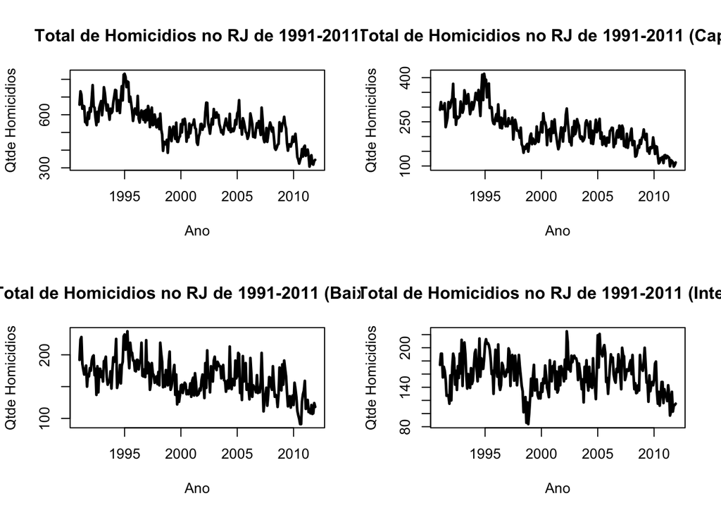

```r
#Plot series
par(mfrow=c(2,2))

plot(rj_murder_total
     ,main = "Total de Homicidios no RJ de 1991-2011"
     ,xlab = "Ano"
     ,ylab = "Qtde Homicidios"
     ,type = "l"
     ,lwd = 2.5
     )


plot(rj_murder_capital
     ,main = "Total de Homicidios no RJ de 1991-2011 (Capital)"
     ,xlab = "Ano"
     ,ylab = "Qtde Homicidios"
     ,type = "l"
     ,lwd = 2.5
)


plot(rj_murder_baixada
     ,main = "Total de Homicidios no RJ de 1991-2011 (Baixada)"
     ,xlab = "Ano"
     ,ylab = "Qtde Homicidios"
     ,type = "l"
     ,lwd = 2.5
)


plot(rj_murder_interior
     ,main = "Total de Homicidios no RJ de 1991-2011 (Interior)"
     ,xlab = "Ano"
     ,ylab = "Qtde Homicidios"
     ,type = "l"
     ,lwd = 2.5
)
```

Agora que vimos que as nossas séries estão corretas, vamos criar alguns objetos usando a função `auto.arima()`.

```r
# Fit ARIMA models
fit_rj_murder_total     <- auto.arima(rj_murder_total)
fit_rj_murder_capital   <- auto.arima(rj_murder_capital)
fit_rj_murder_baixada   <- auto.arima(rj_murder_baixada)
fit_rj_murder_interior  <- auto.arima(rj_murder_interior)
```

Essa função retorna o melhor modelo ARIMA de acordo com os valores de AIC, AICc e BIC.

Mas deixando um pouco a teoria de lado, vamos ver como ficaram os ajustes dos modelos ARIMA de acordo com cada uma das séries.

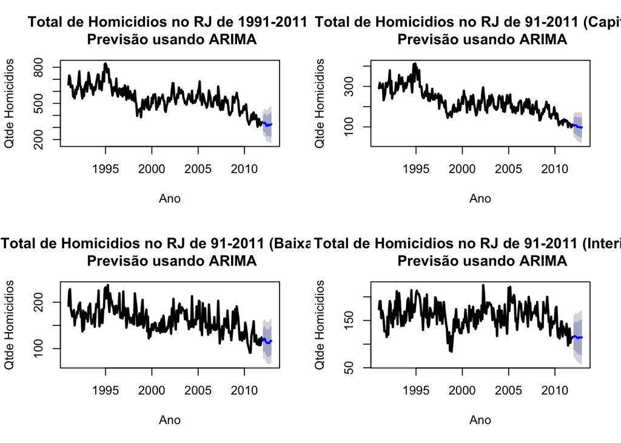

```r
#Plot ARIMA Models
par(mfrow=c(2,2))
plot(forecast(fit_rj_murder_total,h=12)
     ,main = "Total de Homicidios no RJ de 1991-2011 \n Previsão usando ARIMA"
     ,xlab = "Ano"
     ,ylab = "Qtde Homicidios"
     ,type = "l"
     ,lwd = 2.5)

plot(forecast(fit_rj_murder_capital,h=12)
     ,main = "Total de Homicidios no RJ de 91-2011 (Capital) \n Previsão usando ARIMA"
     ,xlab = "Ano"
     ,ylab = "Qtde Homicidios"
     ,type = "l"
     ,lwd = 2.5)

plot(forecast(fit_rj_murder_baixada,h=12)
     ,main = "Total de Homicidios no RJ de 91-2011 (Baixada) \n Previsão usando ARIMA"
     ,xlab = "Ano"
     ,ylab = "Qtde Homicidios"
     ,type = "l"
     ,lwd = 2.5)

plot(forecast(fit_rj_murder_interior,h=12)
     ,main = "Total de Homicidios no RJ de 91-2011 (Interior) \n Previsão usando ARIMA"
     ,xlab = "Ano"
     ,ylab = "Qtde Homicidios"
     ,type = "l"
     ,lwd = 2.5)
```

Um bom resultado, mas agora vamos ver o que conseguimos fazer usando o package `forecast` default, com o horizonte de previsão de 12 meses:

```r
#Forecasting using confidence intervals in 80%, 95% and 99% with 12 months ahead
ahead_rj_murder_total    <- forecast(rj_murder_total, level=c(80, 95, 99), h=12)
ahead_rj_murder_capital  <- forecast(rj_murder_capital, level=c(80, 95, 99), h=12)
ahead_rj_murder_interior <- forecast(rj_murder_interior, level=c(80, 95, 99), h=12)
ahead_rj_murder_baixada  <- forecast(rj_murder_baixada, level=c(80, 95, 99), h=12)
```

Modelos ajustados, vamos plotar:

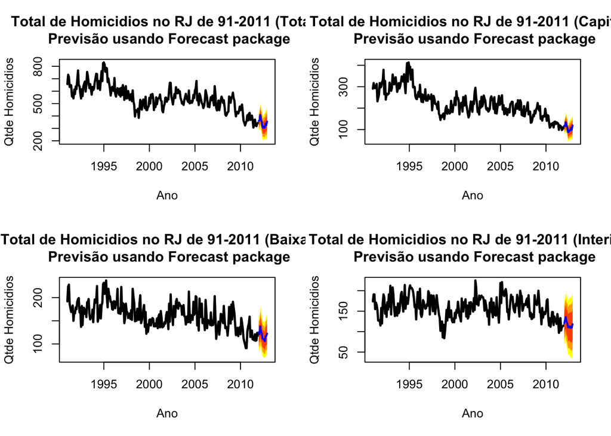

```r
#Plot forecasting
par(mfrow=c(2,2))
plot(ahead_rj_murder_total
     ,main = "Total de Homicidios no RJ de 91-2011 (Total) \n Previsão usando Forecast package"
     ,xlab = "Ano"
     ,ylab = "Qtde Homicidios"
     ,type = "l"
     ,lwd = 2.5
     ,shadecols="oldstyle")

plot(ahead_rj_murder_capital
     ,main = "Total de Homicidios no RJ de 91-2011 (Capital) \n Previsão usando Forecast package"
     ,xlab = "Ano"
     ,ylab = "Qtde Homicidios"
     ,type = "l"
     ,lwd = 2.5
     ,shadecols="oldstyle")

plot(ahead_rj_murder_baixada
     ,main = "Total de Homicidios no RJ de 91-2011 (Baixada) \n Previsão usando Forecast package"
     ,xlab = "Ano"
     ,ylab = "Qtde Homicidios"
     ,type = "l"
     ,lwd = 2.5
     ,shadecols="oldstyle")

plot(ahead_rj_murder_interior
     ,main = "Total de Homicidios no RJ de 91-2011 (Interior) \n Previsão usando Forecast package"
     ,xlab = "Ano"
     ,ylab = "Qtde Homicidios"
     ,type = "l"
     ,lwd = 2.5
     ,shadecols="oldstyle")
```

Com isso podem ser elaboradas (usando mais dados) políticas públicas de segurança.